# FigureYa6rHRsV2

**Author(s)**: Dekang Lv  
**Reviewer(s)**: Ying Ge, Yijing Chen  
**Date**: 2026-01-07

## 1 Academic Citation

If you use this code in your work or research, we kindly request that you cite our publication:

Xiaofan Lu, et al. (2025). FigureYa: A Standardized Visualization Framework for Enhancing Biomedical Data Interpretation and Research Efficiency. iMetaMed. https://doi.org/10.1002/imm3.70005

## 2 需求描述 Requirement description

临床的亚组分析，我想用R做出文章里的样子。

这里只从形式上复现，如果需要计算过程，请参考FigureYa90subgroup。

Clinical subgroup analysis, I’d like to use R to make what it looks like in the article.

It is only reproduced here formally, if you need the calculation process, please refer to FigureYa90subgroup.

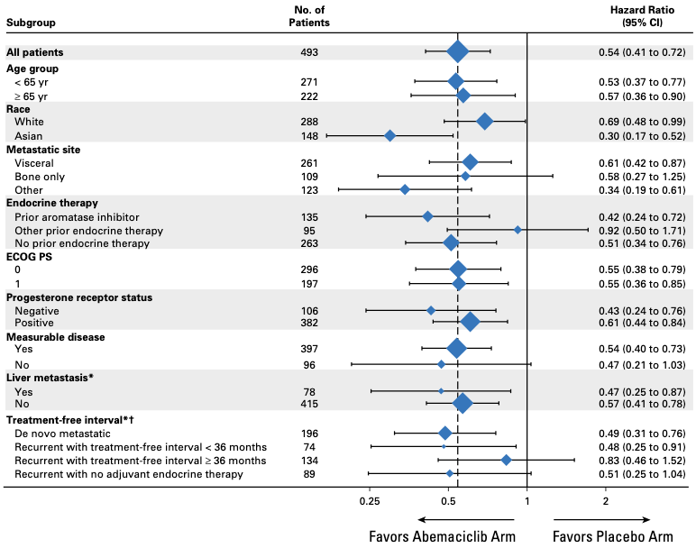

From https://ascopubs.org/doi/full/10.1200/JCO.2017.75.6155?url_ver=Z39.88-2003&rfr_id=ori%3Arid%3Acrossref.org&rfr_dat=cr_pub%3Dpubmed

## 3 应用场景 Application Scenarios

场景一：临床的亚组分析。例如，能从参与临床试验的那么多人当中发现EGFR抑制剂唯独对亚洲非吸烟女性有效。

场景二：meta分析，是经典的meta分析的图。

Scenario 1: Clinical subgroup analysis. For example, it was discovered that among the numerous participants in a clinical trial, EGFR inhibitors were effective only for Asian non-smoking females.

Scenario 2: meta-analysis, a graph of a classic meta-analysis.

## 4 环境设置 Environment setup

```r
source("install_dependencies.R")
```

```
## Starting R package installation...
## ===========================================
##
## Installing CRAN packages...
## Package already installed: checkmate
## Package already installed: forestplot
##
## ===========================================
## Package installation completed!
## You can now run your R scripts in this directory.
```

```r
library("forestplot") # 画森林图 | draw forest plot
Sys.setenv(LANGUAGE = "en") #显示英文报错信息 | Display English error messages
options(stringsAsFactors = FALSE) #禁止chr转成factor | prohibit the conversion of chr to factor
```

## 5 输入文件 Input file

临床数据，包括分类、样本数、风险比及置信区间(上限及下限)等

测试用数据文件为easy_input.csv，分类、样本数、风险比及置信区间(上限及下限)对应的列名分别是Variable、Count、Point.Estimate、Low和High

Clinical data, including categorization, sample size, hazard ratio, and confidence intervals (upper and lower limits), etc.

The data file for testing is easy_input.csv, and the corresponding column names for classification, sample size, hazard ratio, and confidence intervals (upper and lower limits) are Variable, Count, Point.Estimate, Low, and High, respectively.

```r
#读取输入文件，输入数据一般包括分类、样本数、风险比及置信区间（上限及下限）等，需要注意的是输入文件的布局(包括文字缩进)将展示在最后结果中，所见即所得。
#Read the input file, the input data generally includes classification, sample size, hazard ratio and confidence interval (upper and lower limits), etc. It should be noted that the layout of the input file (including text indentation) will be displayed in the final results, what you see is what you get.
data <- read.csv("easy_input.csv", stringsAsFactors=FALSE)
head(data)
```

```
##       Variable Count Percent Point.Estimate  Low High     P
## 1 All patients  2166     100            1.3 0.90 1.50    NA
## 2          Age    NA      NA             NA   NA   NA 0.001
## 3        <= 65  1534      71            1.5 1.05 1.90    NA
## 4         > 65   632      29            0.8 0.60 1.25    NA
## 5          Sex    NA      NA             NA   NA   NA 0.001
## 6         Male  1690      78            1.5 1.05 1.90    NA
```

```r
np <- ifelse(!is.na(data$Count), paste(data$Count," (",data$Percent,")",sep=""), NA)#合并count和percent，这一步非必要 Merge count and percent, this step is not necessary
head(np)
```

```
## [1] "2166 (100)" NA           "1534 (71)"  "632 (29)"   NA
## [6] "1690 (78)"
```

```r
#将要在图中展示的文本
#所见即所得，想显示哪几列，就在cbind里面添加
#the text to be displayed in the diagram
#What you see is what you get, add which columns you want to show in the cbind
tabletext <- cbind(c("\nSubgroup",NA,NA,data$Variable,NA),
                   c("No. of\nPatients (%)",NA,NA,np,NA),
                   c("Hazard Ratio\n(95% CI)",NA,NA,ifelse(!is.na(data$Count), paste(format(data$Point.Estimate,nsmall=2)," (",format(data$Low,nsmall = 2)," to ",format(data$High,nsmall = 2),")",sep=""), NA),NA),
                   #c("P-value", NA, NA, ifelse(data$P < 0.001, "<0.001", round(data$P,3)), NA))
                   c("P-value", NA, NA, data$P, NA)) #如果没有pvalue，就删掉这行 If there is no p-value, delete this line
head(tabletext)
```

```
##      [,1]           [,2]                   [,3]                     [,4]
## [1,] "\nSubgroup"   "No. of\nPatients (%)" "Hazard Ratio\n(95% CI)" "P-value"
## [2,] NA             NA                     NA                       NA
## [3,] NA             NA                     NA                       NA
## [4,] "All patients" "2166 (100)"           "1.30 (0.90 to 1.50)"    NA
## [5,] "Age"          NA                     NA                       "0.001"
## [6,] "   <= 65"     "1534 (71)"            "1.50 (1.05 to 1.90)"    NA
```

## 6 开始画图 Start drawing

用默认参数画图

Draw with default parameters

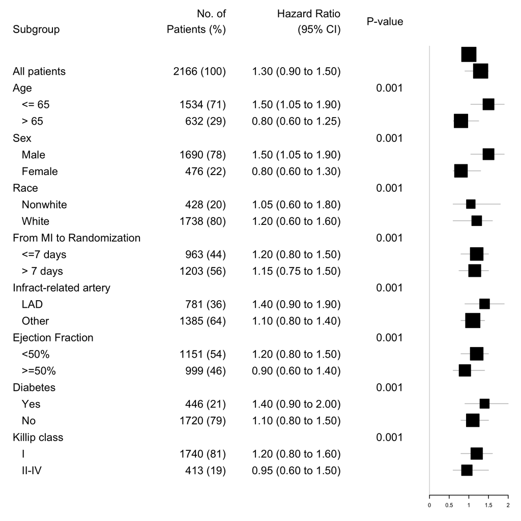

```r
forestplot(labeltext=tabletext, mean=c(NA,NA,1, data$Point.Estimate,NA),
           lower=c(NA,NA,1,data$Low,NA), upper=c(NA,NA,1,data$High,NA))
```

仔细读说明文档，调整参数，就能画出paper里的样子

**重点修改`hrzl_lines`参数里的第三行，画最下面一条黑线，““中数字为nrow(data)+5**

Read the documentation carefully, adjust the parameters, and you’ll be able to draw what you see in the paper

**Focus on modifying the third line in the `hrzl_lines` parameter, draw a black line at the bottom, and the number in “” as nrow(data)+5**

## 7 输出文件 Output file

把森林图输出到pdf文件中，测试的输出文件为forestplot.pdf

Output the forest plot to a pdf file, the output file of the test is forestplot.pdf

```r
pdf("forestplot.pdf",width=12,height = 12)#新建PDF文件，准备写入图形 create a new PDF file and prepare to write graphics
forestplot(labeltext=tabletext, #图中的文本 text in figure
           xlog=TRUE, # 横坐标对数化

           mean=c(NA,NA,1,data$Point.Estimate,NA),#风险比 HR
           lower=c(NA,NA,1,data$Low,NA), #95%置信区间下限 lower limit of 95% confidence interval
           upper=c(NA,NA,1,data$High,NA),#95%置信区间上限 upper limit of 95% confidence interval
           #title="Hazard Ratio",
           graph.pos=3,#图在表中的列位置 column position of the graph in the table
           graphwidth = unit(.4,"npc"),#图在表中的宽度比例 width ratio of the graph in the table
           fn.ci_norm="fpDrawDiamondCI",#box类型选择钻石 box type selection diamond
           col=fpColors(box="steelblue", lines="black", zero = "black"),#box颜色 box color
           boxsize=c(NA,NA,NA,data$Percent,NA)/75,#box大小根据样本量设置 box size is set according to the sample size
           lwd.ci=2,ci.vertices.height = 0.1,ci.vertices=TRUE,#置信区间用线宽、高、型 confidence interval with line width, height, and type
           zero=1,#zero线横坐标 horizontal coordinates of the zero line
           lwd.zero=2,#zero线宽 zero line width
           grid = structure(c(data[1,]$Point.Estimate), gp = gpar(col = "black", lty=2,lwd=2)),#虚线(可多条)及其横坐标、颜色、线宽 dashed lines (can be more than one) and their horizontal coordinates, colors, line widths
           xticks = c(0.75, 1.5),#横坐标刻度根据需要可随意设置  horizontal coordinate scale can be set as freely
           lwd.xaxis = 2,#X轴线宽  X-axis line width
           xlab="     <-Favors A Arm      Favors B Arm->",#X轴标题  X-axis title
           hrzl_lines=list("3" = gpar(lwd=2, col="black"),#第三行顶部加黑线，引号内数字标记行位置 add a black line at the top of the third line, with numbers in quotes indicating the line position
                           #"4" = gpar(lwd=60,lineend="butt", columns=c(1:4), col="#99999922"),#加阴影，弱项不建议使用 add shadows, not recommended for weak items
                           "30" = gpar(lwd=2, col="black")),#最后一行底部加黑线,""中数字为nrow(data)+5 add a black line at the bottom of the last line, with the number in quotes as nrow(data)+5
           txt_gp=fpTxtGp(label=gpar(cex=1.25),#各种字体大小设置 various font size settings
                          ticks=gpar(cex=1.25),
                          xlab=gpar(cex = 1.25),
                          title=gpar(cex = 1.25)),
           #is.summary = c(T,rep(F,27)),#首行字体类型设置 first line font type setting
           lineheight = unit(.75,"cm"),#固定行高 fixed row height
           #align=c("l","c","c"),#每列文字的对齐方式，偶尔会用到 the alignment of the text in each column is occasionally used to
           #cex=10,
           colgap = unit(0,"cm"),#列间隙 column gap
           mar=unit(rep(1.25, times = 4), "cm"),#图形页边距 graphic margin
           new_page = F#是否新页 new page or not
           )
dev.off()#写入图型并关闭PDF文件 write graphics and close the PDF file
```

[figure not shown]